# Cohort Selection

June 2019

*Libraries Used*

```r
library('bigrquery')     # Query data from Google BigQuery
library('knitr')         # Make knited tables ("kables")
library('kableExtra')    # Extra kable formatting options

project <- readRDS(file = 'my-project-name.RDS')
```

# 1 Introduction

## 1.1 Criteria 1: Patients with acute heart failure

To select patients with acute heart failure, we first constructed a cohort of all heart failure patients, denoted by the ICD9 code `4280`, then subtracted those that had an additional chronic heart failure diagnosis (codes `42822, 42823, 42832, 42833, 42842 & 42843`).

```r
sql <- "SELECT *
        FROM [physionet-data.mimiciii_clinical.diagnoses_icd]
        WHERE icd9_code IN ('4280')
        AND hadm_id NOT IN (
            SELECT hadm_id
            FROM [physionet-data.mimiciii_clinical.diagnoses_icd]
            WHERE icd9_code IN ('42822', '42823', '42832', '42833', '42842', '42843')
            GROUP BY hadm_id
        )"

cohort <- query_exec(sql, project=project)
```

Based on this initial query, there are 8059 unique encounters in our cohort representing 6838 individual subjects.

# 2 Out-of-hospital mortality

## 2.1 Data Source

We want to see the mortality of these patients at given time points after their discharge from the hospital. To do this we need two things:

- Their date of discharge (in the admissions table)
- Their date of death (in the patients table)

We’ll have to set up a couple queries using the cohort subject_id as a filter and pull these data from the different tables. In the end we’ll join these together and have a table of patients in our defined cohort with admission date, discharge date, and death date.

```r
# Get data for date of death
sql <- "SELECT *
        FROM [physionet-data.mimiciii_clinical.patients]"

patients <- query_exec(sql, project=project)
```

```
## 0 bytes processed
```

```r
# Get data for date of admission/discharge
sql <- "SELECT SUBJECT_ID, HADM_ID, ADMITTIME, DISCHTIME
        FROM [physionet-data.mimiciii_clinical.admissions]"

admissions <- query_exec(sql, project=project)
```

```
## 0 bytes processed
```

```r
library(dplyr)
library(magrittr)
# Left join with patients in the cohort
cohort1 <- select(patients, -ROW_ID) %>%
  left_join(cohort,., by = "SUBJECT_ID") %>%
  select(-ROW_ID)

cohort1 <- left_join(cohort1, admissions, by = c('HADM_ID', 'SUBJECT_ID'))

head(cohort1)
```

```
##   SUBJECT_ID HADM_ID SEQ_NUM ICD9_CODE GENDER        DOB        DOD
## 1        768  170167       3      4280      F 2109-04-15 2175-03-01
## 2      67072  131177       5      4280      F 2130-06-29       <NA>
## 3       3840  166081       2      4280      M 2062-03-31 2135-01-25
## 4       4096  124383       4      4280      M 2091-09-11       <NA>
## 5       4096  161677       4      4280      M 2091-09-11       <NA>
## 6       4608  110346       2      4280      F 2034-10-09       <NA>
##   DOD_HOSP    DOD_SSN EXPIRE_FLAG           ADMITTIME           DISCHTIME
## 1     <NA> 2175-03-01           1 2175-02-03 19:00:00 2175-02-13 14:45:00
## 2     <NA>       <NA>           0 2192-07-30 17:48:00 2192-08-03 15:00:00
## 3     <NA> 2135-01-25           1 2134-12-22 15:03:00 2134-12-30 13:35:00
## 4     <NA>       <NA>           0 2170-07-20 18:09:00 2170-07-26 13:30:00
## 5     <NA>       <NA>           0 2170-06-05 19:49:00 2170-06-22 16:00:00
## 6     <NA>       <NA>           0 2114-02-04 17:05:00 2114-02-15 13:31:00
```

## 2.2 Removing in hospital mortality

We want to remove all the entries where the patient died in the hospital on that visit. One way is to look to see if their date of death `DOD` was within their time spent in the hospital given by `ADMITTIME` and `DISCHTIME`. If `DOD` is between the dates of admission and discharge the patient died on this hospital visit and will be removed from the dataset.

```r
# Calculate if patient died on that visit to the hospital
library(lubridate)
cohort1 <- cohort1 %>%
  mutate(DIED_ON_VISIT = if_else(DOD %within% c(ADMITTIME %--% DISCHTIME), 1, 0, missing = 0))


# Calculate patient age at discharge
cohort1$AGE <- round((cohort1$DISCHTIME - cohort1$DOB)/365, 1)

# Calculate how long patient was admitted for each visit
cohort1$DAYS_ADMITTED <- difftime(cohort1$DISCHTIME, cohort1$ADMITTIME, units = 'days') %>% round(., 1)
```

## 2.3 Determining time from discharge to death

We want to look at mortality at different time points after discharge from the hospital. To do this we’ll calculate the number of days from discharge to death for all visits to the hospital and then convert these into binary mortality values (0 for alive, 1 for deceased) at specified time points (72h, 1 week, 1 month, 6 months, 1 year).

For example a patient that died 3 months after discharge would have mortality values of:

- 72 hours: 0
- 1 week: 0
- 1 month: 0
- 6 months: 1
- 1 year: 1

```r
# Calculate length of time between discharge and death (converted to days)
cohort1$MORTALITY_AFTER_DISCH_DAYS <- round((cohort1$DOD - cohort1$DISCHTIME) /(60*60*24), digits = 2)



# Calculate mortality at 72h (3 days), 1 week, 1 month, 6 months, 1 year
cohort1$MORTALITY_3D <- if_else(cohort1$MORTALITY_AFTER_DISCH_DAYS <= 3, 1, 0, missing = 0)
cohort1$MORTALITY_7D <- if_else(cohort1$MORTALITY_AFTER_DISCH_DAYS <= 7, 1, 0, missing = 0)
cohort1$MORTALITY_30D <- if_else(cohort1$MORTALITY_AFTER_DISCH_DAYS <= 30, 1, 0, missing = 0)
cohort1$MORTALITY_180D <- if_else(cohort1$MORTALITY_AFTER_DISCH_DAYS <= 180, 1, 0, missing = 0)
cohort1$MORTALITY_365D <- if_else(cohort1$MORTALITY_AFTER_DISCH_DAYS <= 365, 1, 0, missing = 0)
```

The values of `MORTALITY_AFTER_DISCH_DAYS` give days for patients that died and `NA` for patients who are alive. We’ll give living patients a large number (10,000) so that when we do some filtering (removing negative values of `MORTALITY_AFTER_DISCH_DAYS` especially) it won’t remove living patients.

```r
# Convert living patients to have mortality after discharge time of 10000
# Need to do this for filtering out the negative mortality after discharge times
cohort1$MORTALITY_AFTER_DISCH_DAYS <- coalesce(cohort1$MORTALITY_AFTER_DISCH_DAYS, 10000)
```

## 2.4 Filtering the cohort

Now that we have the mortality at different time points calculated, we need to filter the cohort based on our criteria:

- Age > 18
- Patient did not die on the visit

Also with age all patients over 90 years old have been converted in the dataset to age > 300 for confidentiality reasons. We’ll filter out patients with age > 100 to account for this.

```r
# Cohort filtering
cohort1 <- filter(cohort1, MORTALITY_AFTER_DISCH_DAYS >= 0) %>%  # Remove negative mortality times
  filter(AGE < 100 & AGE > 18) %>%   # Filter age 18 to 89
  filter(!DIED_ON_VISIT == 1)        # Remove in hospital mortality


head(cohort1)
```

```
##   SUBJECT_ID HADM_ID SEQ_NUM ICD9_CODE GENDER        DOB        DOD
## 1        768  170167       3      4280      F 2109-04-15 2175-03-01
## 2      67072  131177       5      4280      F 2130-06-29       <NA>
## 3       3840  166081       2      4280      M 2062-03-31 2135-01-25
## 4       4096  124383       4      4280      M 2091-09-11       <NA>
## 5       4096  161677       4      4280      M 2091-09-11       <NA>
## 6       4608  110346       2      4280      F 2034-10-09       <NA>
##   DOD_HOSP    DOD_SSN EXPIRE_FLAG           ADMITTIME           DISCHTIME
## 1     <NA> 2175-03-01           1 2175-02-03 19:00:00 2175-02-13 14:45:00
## 2     <NA>       <NA>           0 2192-07-30 17:48:00 2192-08-03 15:00:00
## 3     <NA> 2135-01-25           1 2134-12-22 15:03:00 2134-12-30 13:35:00
## 4     <NA>       <NA>           0 2170-07-20 18:09:00 2170-07-26 13:30:00
## 5     <NA>       <NA>           0 2170-06-05 19:49:00 2170-06-22 16:00:00
## 6     <NA>       <NA>           0 2114-02-04 17:05:00 2114-02-15 13:31:00
##   DIED_ON_VISIT       AGE DAYS_ADMITTED MORTALITY_AFTER_DISCH_DAYS
## 1             0 65.9 days      9.8 days                 15.39 secs
## 2             0 62.1 days      3.9 days              10000.00 secs
## 3             0 72.8 days      7.9 days                 25.43 secs
## 4             0 78.9 days      5.8 days              10000.00 secs
## 5             0 78.8 days     16.8 days              10000.00 secs
## 6             0 79.4 days     10.9 days              10000.00 secs
##   MORTALITY_3D MORTALITY_7D MORTALITY_30D MORTALITY_180D MORTALITY_365D
## 1            0            0             1              1              1
## 2            0            0             0              0              0
## 3            0            0             1              1              1
## 4            0            0             0              0              0
## 5            0            0             0              0              0
## 6            0            0             0              0              0
```

## 2.5 Summary of cohort

After filtering there are 6150 hospital visits by 5197 unique patients.

```r
# Make a summary table of mortality
summarytable <- data.frame('Time_days' = c(3, 7, 30, 180, 365),
                           'n_Mortality' = c(sum(cohort1$MORTALITY_3D),
                                           sum(cohort1$MORTALITY_7D),
                                           sum(cohort1$MORTALITY_30D),
                                           sum(cohort1$MORTALITY_180D),
                                           sum(cohort1$MORTALITY_365D)))

summarytable$Percent_mortality <- 100*round(summarytable$n_Mortality/8059, 3)

kable(summarytable) %>%
  kable_styling(bootstrap_options = 'striped')
```

| Time_days | n_Mortality | Percent_mortality |
| --- | --- | --- |
| 3 | 89 | 1.1 |
| 7 | 164 | 2.0 |
| 30 | 423 | 5.2 |
| 180 | 1178 | 14.6 |
| 365 | 1636 | 20.3 |

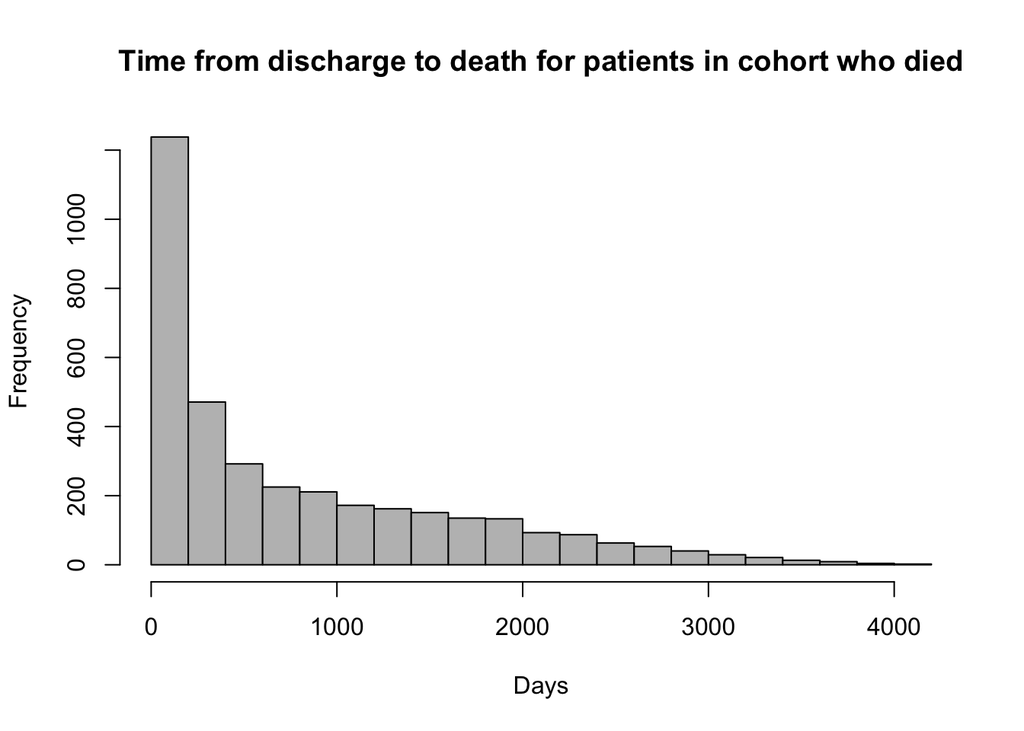

```r
# Look at distribution of time to death after discharge in those that died
test <- cohort1 %>%
  filter(EXPIRE_FLAG == 1)
hist(as.numeric(test$MORTALITY_AFTER_DISCH_DAYS),
     breaks = 20,
     col = 'gray',
     main = 'Time from discharge to death for patients in cohort who died',
     xlab = 'Days')
```

## 2.6 Comments

Thoughts: